# Planning Public Policy in Argentina

## 1. Provinces of Argentina

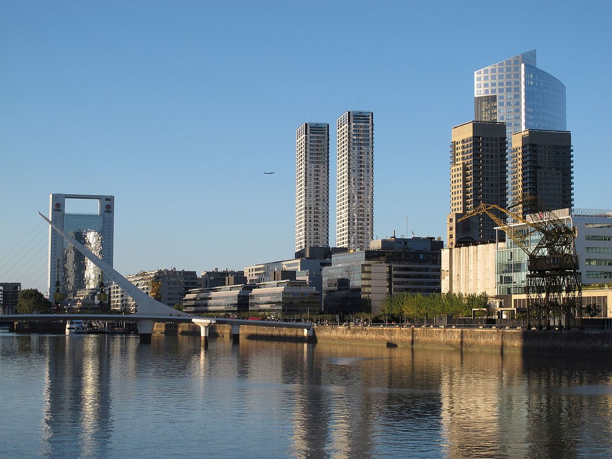

With almost 40 million inhabitants and a diverse geography that encompasses the Andes mountains, glacial lakes, and the Pampas grasslands, Argentina is the second largest country (by area) and has one of the largest economies in South America. It is politically organized as a federation of 23 provinces and an autonomous city, Buenos Aires.

We will analyze ten economic and social indicators collected for each province. Because these indicators are highly correlated, we will use Principal Component Analysis (PCA) to reduce redundancies and highlight patterns that are not apparent in the raw data. After visualizing the patterns, we will use k-means clustering to partition the provinces into groups with similar development levels.

These results can be used to plan public policy by helping allocate resources to develop infrastructure, education, and welfare programs.

**Setup**

```r
# Load the tidyverse
library(tidyverse)

# Read in the dataset
argentina <- read_csv("datasets/argentina.csv")
```

```r
# Inspect the first rows of the dataset
head(argentina)
```

```
## # A tibble: 6 x 11
##   province    gdp illiteracy poverty deficient_infra school_dropout
##   <chr>     <dbl>      <dbl>   <dbl>           <dbl>          <dbl>
## 1 Buenos … 2.93e8       1.38    8.17            5.51          0.766
## 2 Catamar… 6.15e6       2.34    9.23           10.5           0.952
## 3 Córdoba  6.94e7       2.71    5.38           10.4           1.04
## 4 Corrien… 7.97e6       5.60   12.7            17.4           3.86
## 5 Chaco    9.83e6       7.52   15.9            31.5           2.58
## 6 Chubut   1.77e7       1.55    8.05            8.04          0.586
## # … with 5 more variables: no_healthcare <dbl>, birth_mortal <dbl>,
## #   pop <dbl>, movie_theatres_per_cap <dbl>, doctors_per_cap <dbl>
```

## 2. Most populous, richest provinces

Argentina ranks third in South America in total population, but the population is unevenly distributed throughout the country. Sixty percent of the population resides in the Pampa region (Buenos Aires, La Pampa, Santa Fe, Entre Ríos and Córdoba) which only encompasses about 20% of the land area.

[GDP](https://en.wikipedia.org/wiki/Gross_domestic_product) is a measure of the size of a province’s economy. To measure how rich or poor the inhabitants are, economists use *per capita GDP*, which is GDP divided by the province’s population.

```r
# Add gdp_per_capita column to argentina
argentina <- argentina %>%
  mutate(gdp_per_cap = gdp / pop)
```

```r
# Find the four richest provinces
( rich_provinces  <- argentina %>%
  arrange(-gdp_per_cap) %>%
  select(province, gdp_per_cap) %>%
  top_n(4) )
```

```
## # A tibble: 4 x 2
##   province   gdp_per_cap
##   <chr>            <dbl>
## 1 Santa Cruz        42.6
## 2 Neuquén           40.9
## 3 Chubut            34.9
## 4 San Luis          27.3
```

```r
# Find the provinces with populations over 1 million
( bigger_pops <- argentina %>%
  arrange(pop) %>%
  select(province, pop) %>%
  filter(pop > 1000000) )
```

```
## # A tibble: 9 x 2
##   province          pop
##   <chr>           <dbl>
## 1 Chaco         1055259
## 2 Misiones      1101593
## 3 Salta         1214441
## 4 Entre Ríos    1235994
## 5 Tucumán       1448188
## 6 Mendoza       1738929
## 7 Santa Fe      3194537
## 8 Córdoba       3308876
## 9 Buenos Aires 15625084
```

## 3. A matrix for PCA

Principal Component Analysis (PCA) is an unsupervised learning technique that summarizes multivariate data by reducing redundancies (variables that are correlated). New variables (the principal components) are linear combinations of the original data that retain as much variation as possible. We would imagine that some aspects of economic and social data would be highly correlated, so let’s see what pops out. But first, we need to do some data preparation.

R makes it easy to run a PCA with the `PCA()` function from the `FactoMineR` package. The first argument in `PCA()` is a data frame or matrix of the data where the rows are “individuals” (or in our case, provinces) and columns are numeric variables. To prepare for the analysis, we will remove the column of province names and build a matrix from the dataset.

```r
# Select numeric columns and cast to matrix
argentina_matrix  <- argentina  %>%
  select_if(is.numeric) %>%
  as.matrix()

# Print the first lines of the result
head(argentina_matrix)
```

```
##            gdp illiteracy   poverty deficient_infra school_dropout
## [1,] 292689868    1.38324  8.167798        5.511856      0.7661682
## [2,]   6150949    2.34414  9.234095       10.464484      0.9519631
## [3,]  69363739    2.71414  5.382380       10.436086      1.0350558
## [4,]   7968013    5.60242 12.747191       17.438858      3.8642652
## [5,]   9832643    7.51758 15.862619       31.479527      2.5774621
## [6,]  17747854    1.54806  8.051752        8.044618      0.5863094
##      no_healthcare birth_mortal      pop movie_theatres_per_cap
## [1,]       48.7947          4.4 15625084         0.000006015968
## [2,]       45.0456          1.5   367828         0.000005437324
## [3,]       45.7640          4.8  3308876         0.000011182045
## [4,]       62.1103          5.9   992595         0.000004029841
## [5,]       65.5104          7.5  1055259         0.000002842904
## [6,]       39.5473          3.0   509108         0.000015713758
##      doctors_per_cap gdp_per_cap
## [1,]     0.004835622   18.732051
## [2,]     0.004502104   16.722352
## [3,]     0.010175359   20.962931
## [4,]     0.004495288    8.027456
## [5,]     0.003604802    9.317753
## [6,]     0.004498063   34.860686
```

## 4. Reducing dimensions

PCA finds a lower dimensional representation of the data that keeps the maximum amount of variance. It’s great for analyzing multivariate datasets, like this one, with multiple numerical columns that are highly correlated. Typically, the first few components preserve most of the information in the raw data, allowing us, to go from eleven dimensions (eleven original variables) down to two dimensions (two variables that are summaries of the original eleven).

To run PCA, we need to make sure all the variables are on similar scales. Otherwise, variables with large variance will be overrepresented. In `PCA()` setting `scale.unit = TRUE` ensures that variables are scaled to unit variance before crunching the numbers.

Feel free to explore the output!

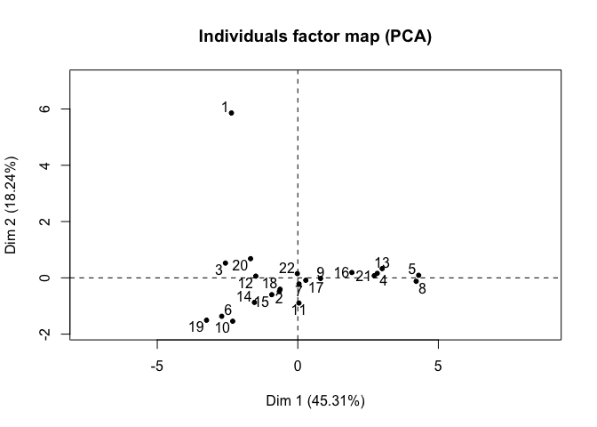

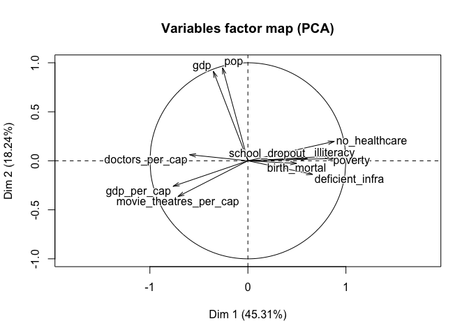

```
## **Results for the Principal Component Analysis (PCA)**
## The analysis was performed on 22 individuals, described by 11 variables
## *The results are available in the following objects:
##
##    name               description
## 1  "$eig"             "eigenvalues"
## 2  "$var"             "results for the variables"
## 3  "$var$coord"       "coord. for the variables"
## 4  "$var$cor"         "correlations variables - dimensions"
## 5  "$var$cos2"        "cos2 for the variables"
## 6  "$var$contrib"     "contributions of the variables"
## 7  "$ind"             "results for the individuals"
## 8  "$ind$coord"       "coord. for the individuals"
## 9  "$ind$cos2"        "cos2 for the individuals"
## 10 "$ind$contrib"     "contributions of the individuals"
## 11 "$call"            "summary statistics"
## 12 "$call$centre"     "mean of the variables"
## 13 "$call$ecart.type" "standard error of the variables"
## 14 "$call$row.w"      "weights for the individuals"
## 15 "$call$col.w"      "weights for the variables"
```

```r
# Load FactoMineR
library(FactoMineR)

# Apply PCA and print results
( argentina_pca  <- PCA(argentina_matrix, scale.unit = TRUE) )
```